# Documentation

Philipp Münker

2025-05-25

## Loading Librarys

```r
library(readxl) # zum einlesen von Excel Dateien
library(tidyverse) # Visualisierungen
source("R/models.R") # Unsere eigenen Modelle laden
```

## Daten Vorbereiten

```r
path = "Data/Database.xlsx" # Pfad zur Datenbank
metainfo_path = "Data/MetaDataComplete.csv" # Pfand zur Metainfo

# 1. Daten einlesen
# ---------------------------------------------------------
# Excel-Datei einlesen

df_datenbank = read_excel(path) # Datenbank
df_metainformation = read.csv(metainfo_path) # Metainfo
```

Schauen wir und die eingelesenen Daten an. Welche Namen haben die Spalten ? Wie sind die Dimensionen? Welche Variablentypen gibt es ?

```r
# Database
names(df_datenbank) # zeigt alle Spaltennamen
```

```
##  [1] "Site"                   "Ton"                    "Sand"
##  [4] "K_percent"              "U_ppm"                  "Th_ppm"
##  [7] "TC_merged_cps"          "Geologie_1_5Mio_EU_Map" "Geologie_1_5Mio_BGR"
## [10] "Geologie_1_5Mio"        "Geologie_SP1"           "Geologie_SP2_Substrat"
## [13] "CaCO3_prozent"          "CaCO3_class"            "Labor-Nr Bobo_ID"
## [16] "K_Th_Ratio"
```

```r
# Metainformationen
names(df_metainformation) # zeigt alle Spaltennamen
```

```
##  [1] "X"             "Location"      "Lat"           "Lon"
##  [5] "AgeName"       "Portr_AGE"     "Portr_Petr"    "MARIN"
##  [9] "AgeOldest"     "AgeNewest"     "Nummer"        "Era"
## [13] "Clay"          "Sand"          "Silt"          "K_percent"
## [17] "U_ppm"         "Th_ppm"        "TC_merged_cps" "K_Th_Ratio"
## [21] "Country"       "District"
```

Jetzt können wir uns die Dimensionen beider Dataframes anschauen.

```r
print(dim(df_datenbank)) # dim datenbank (Zeilen, Spalten)
```

```
## [1] 967  16
```

```r
print(dim(df_metainformation)) # dim datenbank (Zeilen, Spalten)
```

```
## [1] 39 22
```

Als nächstes kann man prüfen, welche Sites sich in der Database und in den Metainfos befindenn.

```r
print(unique(df_datenbank$Site)) # Sites Datenbank
```

```
##  [1] "Aschaffenburg - Johannesberg 1 Grünland"
##  [2] "Aschaffenburg - Johannesberg 2 Acker - 20210325"
##  [3] "Ascheberg"
##  [4] "Bölingen"
##  [5] "Dürnast"
##  [6] "Göttingen - 20210326"
##  [7] "Heimbach Hergarten"
##  [8] "Mainz - Sprendlingen - 20190320_Zero"
##  [9] "Marktheidenfeld"
## [10] "Neustadt W - Ruppertsberg - 20210319"
## [11] "Erwitte 1 (steinig), SH_ost"
## [12] "Gent_JBD"
## [13] "Gent_JBQ"
## [14] "Gent_JBT"
## [15] "Gent_JBV"
```

[output cut: 23 more lines]

```r
print(unique(df_metainformation$Location)) # Sites Metainfo
```

```
##  [1] "Aschaffenburg - Johannesberg 1 Grünland"
##  [2] "Aschaffenburg - Johannesberg 2 Acker - 20210325"
##  [3] "Ascheberg"
##  [4] "Bölingen"
##  [5] "Dürnast"
##  [6] "Göttingen - 20210326"
##  [7] "Heimbach Hergarten"
##  [8] "Mainz - Sprendlingen - 20190320_Zero"
##  [9] "Marktheidenfeld"
## [10] "Neustadt W - Ruppertsberg - 20210319"
## [11] "Lux_M_KG"
## [12] "LuxM_FF"
## [13] "Erwitte 1 (steinig), SH_ost"
## [14] "Gent_JBD"
## [15] "Gent_JBQ"
```

[output cut: 24 more lines]

Man sieht, dass die Metainfos einen Standort mehr enthalten, was aber nicht schlimm ist. Wir möchten später die Sites in unserer Datenbank um die Metainformationen erweitern. Wichtig ist nur, dass alle Sites in unserer Datenbank in der Metadatenbank repräsentiert sind. Das kann man auch leicht überprüfen. Wir verweden dazu einfach `setdiff()`.

```r
print(setdiff(unique(df_datenbank$Site),unique(df_metainformation$Location) )) #
```

```
## character(0)
```

Hier kommt `character(0)` raus, was zeigt, dass in unserer Datenbank keine Site ist, die nicht in den Metainfos abgedeckt ist! Jetzt bauen wir ein großes df zusammen.

```r
# 1. Metainformationen hinzufügen
# ---------------------------------------------------------
# Relevante Metadaten auswählen

meta_ausgewählt = df_metainformation[, c(
  "Location",
  "AgeName",
  "Portr_AGE",
  "Portr_Petr",
  "AgeOldest",
  "AgeNewest",
  "Era",
  "District"
)]


df_mit_meta = merge(df_datenbank, meta_ausgewählt,
                     by.x = "Site", by.y = "Location",
                     all.x = TRUE)
```

Schauen wir uns von dem neuen Dataframe mal die Spaltennamen an.

```r
names(df_mit_meta)
```

```
##  [1] "Site"                   "Ton"                    "Sand"
##  [4] "K_percent"              "U_ppm"                  "Th_ppm"
##  [7] "TC_merged_cps"          "Geologie_1_5Mio_EU_Map" "Geologie_1_5Mio_BGR"
## [10] "Geologie_1_5Mio"        "Geologie_SP1"           "Geologie_SP2_Substrat"
## [13] "CaCO3_prozent"          "CaCO3_class"            "Labor-Nr Bobo_ID"
## [16] "K_Th_Ratio"             "AgeName"                "Portr_AGE"
## [19] "Portr_Petr"             "AgeOldest"              "AgeNewest"
## [22] "Era"                    "District"
```

Im Weiteren müssen noch NAs bereinigt werden!

```r
# 2. Analyse der fehlenden Werte
# ---------------------------------------------------------
# Gesamtzahl fehlender Werte

print(paste("Gesamtzahl der NAs:", sum(is.na(df_mit_meta))))
```

```
## [1] "Gesamtzahl der NAs: 2028"
```

```r
# Detaillierte Analyse fehlender Werte pro Spalte
na_counts = sapply(df_mit_meta, function(x) sum(is.na(x)))
na_summary = data.frame(
  Spalte = names(na_counts),
  Anzahl_NAs = na_counts
)
print("NA-Analyse pro Spalte:")
```

```
## [1] "NA-Analyse pro Spalte:"
```

```r
print(na_summary[order(-na_summary$Anzahl_NAs), ])
```

```
##                                        Spalte Anzahl_NAs
## CaCO3_class                       CaCO3_class        928
## CaCO3_prozent                   CaCO3_prozent        423
## Geologie_SP1                     Geologie_SP1        351
## Geologie_1_5Mio               Geologie_1_5Mio        284
## U_ppm                                   U_ppm         36
## Ton                                       Ton          1
## Sand                                     Sand          1
## K_percent                           K_percent          1
## Th_ppm                                 Th_ppm          1
## TC_merged_cps                   TC_merged_cps          1
## K_Th_Ratio                         K_Th_Ratio          1
## Site                                     Site          0
## Geologie_1_5Mio_EU_Map Geologie_1_5Mio_EU_Map          0
## Geologie_1_5Mio_BGR       Geologie_1_5Mio_BGR          0
## Geologie_SP2_Substrat   Geologie_SP2_Substrat          0
## Labor-Nr Bobo_ID             Labor-Nr Bobo_ID          0
## AgeName                               AgeName          0
## Portr_AGE                           Portr_AGE          0
## Portr_Petr                         Portr_Petr          0
## AgeOldest                           AgeOldest          0
## AgeNewest                           AgeNewest          0
## Era                                       Era          0
## District                             District          0
```

```r
# 3. Spalten entfernen
# ---------------------------------------------------------
# Bestimmte Spalten entfernen

spalten_zu_entfernen = c("CaCO3_prozent", "CaCO3_class",
                          "Geologie_SP1", "Geologie_1_5Mio")
df_mit_meta_pro = df_mit_meta[, -which(names(df_mit_meta) %in% spalten_zu_entfernen)]

print("Entfernte Spalten:")
```

```
## [1] "Entfernte Spalten:"
```

```r
print(spalten_zu_entfernen)
```

```
## [1] "CaCO3_prozent"   "CaCO3_class"     "Geologie_SP1"    "Geologie_1_5Mio"
```

```r
print(paste("Finale Dimensionen:", paste(dim(df_mit_meta_pro), collapse=" x ")))
```

```
## [1] "Finale Dimensionen: 967 x 19"
```

```r
# 4. Überprüfung der finalen Daten
# ---------------------------------------------------------
# Überprüfen der fehlenden Werte im finalen Dataframe

na_counts_final = sapply(df_mit_meta_pro, function(x) sum(is.na(x)))
na_summary_final = data.frame(
  Spalte = names(na_counts_final),
  Anzahl_NAs = na_counts_final
)
print("NA-Analyse im finalen Dataframe:")
```

```
## [1] "NA-Analyse im finalen Dataframe:"
```

```r
print(na_summary_final[order(-na_summary_final$Anzahl_NAs), ])
```

```
##                                        Spalte Anzahl_NAs
## U_ppm                                   U_ppm         36
## Ton                                       Ton          1
## Sand                                     Sand          1
## K_percent                           K_percent          1
## Th_ppm                                 Th_ppm          1
## TC_merged_cps                   TC_merged_cps          1
## K_Th_Ratio                         K_Th_Ratio          1
## Site                                     Site          0
## Geologie_1_5Mio_EU_Map Geologie_1_5Mio_EU_Map          0
## Geologie_1_5Mio_BGR       Geologie_1_5Mio_BGR          0
## Geologie_SP2_Substrat   Geologie_SP2_Substrat          0
## Labor-Nr Bobo_ID             Labor-Nr Bobo_ID          0
## AgeName                               AgeName          0
## Portr_AGE                           Portr_AGE          0
## Portr_Petr                         Portr_Petr          0
## AgeOldest                           AgeOldest          0
## AgeNewest                           AgeNewest          0
## Era                                       Era          0
## District                             District          0
```

```r
# 5. clean_colnames funktion
# ---------------------------------------------------------
#

clean_colnames = function(x) {
  x = gsub(" ", "_", x)  # Leerzeichen zu Unterstrich
  x = gsub(",", "", x)   # Kommas entfernen
  x = gsub("-", "_", x)  # Bindestriche zu Unterstrich
  x = make.names(x, unique=TRUE)  # R-konforme Namen erstellen
  x
}
```

```r
# 7. dummy variablen erzeugen
# ---------------------------------------------------------
#


dummy = dummyVars(" ~ Geologie_1_5Mio_EU_Map + Geologie_1_5Mio_BGR + Geologie_SP2_Substrat + AgeName + Portr_Petr + Era + District", data = df_mit_meta_pro)
geology_dummies = predict(dummy, df_mit_meta_pro)
colnames(geology_dummies) = clean_colnames(colnames(geology_dummies))

df_transformed = cbind(
  df_mit_meta_pro[, c("Sand","Ton", "K_percent", "Th_ppm", "K_Th_Ratio", "TC_merged_cps")],  # numerische Spalten
  geology_dummies  # One-Hot encoded Spalten
)

df_transformed[,c("Site","Labor-Nr Bobo_ID")] = df_mit_meta_pro[,c("Site","Labor-Nr Bobo_ID")]
```

Schauen wir uns jetzt das fertig zusammengebaute Dataframe an!

```r
print(names(df_transformed)) #Spaltennamen
```

```
##  [1] "Sand"
##  [2] "Ton"
##  [3] "K_percent"
##  [4] "Th_ppm"
##  [5] "K_Th_Ratio"
##  [6] "TC_merged_cps"
##  [7] "Geologie_1_5Mio_EU_Mapeolian_sand_peat"
##  [8] "Geologie_1_5Mio_EU_Mapglaciofluvial_deposits"
##  [9] "Geologie_1_5Mio_EU_Mapigneous_rocks_Palaeozoic_sedimentary_rocks"
## [10] "Geologie_1_5Mio_EU_Maploess_eluvial_deposits"
## [11] "Geologie_1_5Mio_EU_Maploess_Tertiary_sedimentary_rocks"
## [12] "Geologie_1_5Mio_EU_Mapmarine_deposits_peat"
## [13] "Geologie_1_5Mio_EU_MapMesozoic_calcareous_rocks"
## [14] "Geologie_1_5Mio_EU_MapMesozoic_sedimentary_rocks"
## [15] "Geologie_1_5Mio_EU_Mapmorainic_deposits"
```

[output cut: 69 more lines]

```r
print(dim(df_transformed)) #Dimensionen
```

```
## [1] 967  84
```

```r
print(unique(df_transformed$Site)) #alle Sites
```

```
##  [1] "Aschaffenburg - Johannesberg 1 Grünland"
##  [2] "Aschaffenburg - Johannesberg 2 Acker - 20210325"
##  [3] "Ascheberg"
##  [4] "Ascheberg West"
##  [5] "Bölingen"
##  [6] "Cologne"
##  [7] "Dürnast"
##  [8] "Erwitte 1 (steinig), SH_ost"
##  [9] "Gent_JBD"
## [10] "Gent_JBQ"
## [11] "Gent_JBT"
## [12] "Gent_JBV"
## [13] "Gent_JCK"
## [14] "Gent_JJA"
## [15] "Gent_JJB"
```

[output cut: 23 more lines]

## Pipeline

```r
features =  c("K_percent",
              "Th_ppm",
              "K_Th_Ratio",
              "TC_merged_cps",
              colnames(geology_dummies)) # features festlegen

print(features[1:10]) # die ersten 10 anschauen
```

```
##  [1] "K_percent"
##  [2] "Th_ppm"
##  [3] "K_Th_Ratio"
##  [4] "TC_merged_cps"
##  [5] "Geologie_1_5Mio_EU_Mapeolian_sand_peat"
##  [6] "Geologie_1_5Mio_EU_Mapglaciofluvial_deposits"
##  [7] "Geologie_1_5Mio_EU_Mapigneous_rocks_Palaeozoic_sedimentary_rocks"
##  [8] "Geologie_1_5Mio_EU_Maploess_eluvial_deposits"
##  [9] "Geologie_1_5Mio_EU_Maploess_Tertiary_sedimentary_rocks"
## [10] "Geologie_1_5Mio_EU_Mapmarine_deposits_peat"
```

```r
print(length(features)) # wie viele features hab ich ?
```

```
## [1] 80
```

```r
target = "Ton" # Zielvaribale festlegen
```

Jetzt können wir auch schon damit beginnen unsere Pipeline zu erzeugen.

```r
str(df_transformed) # unsere Daten anschauen -> hier sind features und Target enthalten !
```

```
## 'data.frame':    967 obs. of  84 variables:
##  $ Sand                                                                       : num  49.9 72.9 68.1 72.3 60 ...
##  $ Ton                                                                        : num  15.77 9.52 11.15 9.81 13.02 ...
##  $ K_percent                                                                  : num  1.18 1.59 1.22 1.31 1.33 ...
##  $ Th_ppm                                                                     : num  8.23 8.33 9.28 8.46 9.06 ...
##  $ K_Th_Ratio                                                                 : num  0.143 0.191 0.132 0.155 0.147 ...
##  $ TC_merged_cps                                                              : num  1138 1286 1215 1231 1265 ...
##  $ Geologie_1_5Mio_EU_Mapeolian_sand_peat                                     : num  0 0 0 0 0 0 0 0 0 0 ...
##  $ Geologie_1_5Mio_EU_Mapglaciofluvial_deposits                               : num  0 0 0 0 0 0 0 0 0 0 ...
##  $ Geologie_1_5Mio_EU_Mapigneous_rocks_Palaeozoic_sedimentary_rocks           : num  1 1 1 1 1 1 1 1 1 1 ...
##  $ Geologie_1_5Mio_EU_Maploess_eluvial_deposits                               : num  0 0 0 0 0 0 0 0 0 0 ...
##  $ Geologie_1_5Mio_EU_Maploess_Tertiary_sedimentary_rocks                     : num  0 0 0 0 0 0 0 0 0 0 ...
##  $ Geologie_1_5Mio_EU_Mapmarine_deposits_peat                                 : num  0 0 0 0 0 0 0 0 0 0 ...
##  $ Geologie_1_5Mio_EU_MapMesozoic_calcareous_rocks                            : num  0 0 0 0 0 0 0 0 0 0 ...
##  $ Geologie_1_5Mio_EU_MapMesozoic_sedimentary_rocks                           : num  0 0 0 0 0 0 0 0 0 0 ...
```

[output cut: 70 more lines]

```r
# Initialisiere die Pipeline
rf_pipeline = RandomForestPipeline_New$new(
  data = df_transformed,
  target = target,
  features = features
)
```

```
## [2025-05-27 21:57:21.070747] Datensatzbereinigung: 965 von 967 Zeilen behalten (99.8%)
## [2025-05-27 21:57:21.071204] Neue Pipeline erzeugt.
## [2025-05-27 21:57:21.071296] Zielvariable: Ton
## [2025-05-27 21:57:21.071379] Features: K_percent, Th_ppm, K_Th_Ratio, TC_merged_cps, Geologie_1_5Mio_EU_Mapeolian_sand_peat, ... (75 weitere Features)
```

```r
# Ein paar checks
rf_pipeline$check_sites()
```

```
## [2025-05-27 21:57:21.0727] Aktuelle Sites im Datensatz:
##  [1] "Aschaffenburg - Johannesberg 1 Grünland"
##  [2] "Aschaffenburg - Johannesberg 2 Acker - 20210325"
##  [3] "Ascheberg"
##  [4] "Ascheberg West"
##  [5] "Bölingen"
##  [6] "Cologne"
##  [7] "Dürnast"
##  [8] "Erwitte 1 (steinig), SH_ost"
##  [9] "Gent_JBD"
## [10] "Gent_JBQ"
## [11] "Gent_JBT"
## [12] "Gent_JBV"
## [13] "Gent_JCK"
## [14] "Gent_JJA"
```

[output cut: 24 more lines]

```r
rf_pipeline$features
```

```
##  [1] "K_percent"
##  [2] "Th_ppm"
##  [3] "K_Th_Ratio"
##  [4] "TC_merged_cps"
##  [5] "Geologie_1_5Mio_EU_Mapeolian_sand_peat"
##  [6] "Geologie_1_5Mio_EU_Mapglaciofluvial_deposits"
##  [7] "Geologie_1_5Mio_EU_Mapigneous_rocks_Palaeozoic_sedimentary_rocks"
##  [8] "Geologie_1_5Mio_EU_Maploess_eluvial_deposits"
##  [9] "Geologie_1_5Mio_EU_Maploess_Tertiary_sedimentary_rocks"
## [10] "Geologie_1_5Mio_EU_Mapmarine_deposits_peat"
## [11] "Geologie_1_5Mio_EU_MapMesozoic_calcareous_rocks"
## [12] "Geologie_1_5Mio_EU_MapMesozoic_sedimentary_rocks"
## [13] "Geologie_1_5Mio_EU_Mapmorainic_deposits"
## [14] "Geologie_1_5Mio_EU_MapPalaeozoic_metamorphic_rocks"
## [15] "Geologie_1_5Mio_EU_MapTertiary_molasse_glaciofluvial_deposits"
```

[output cut: 65 more lines]

```r
rf_pipeline$target
```

```
## [1] "Ton"
```

```r
#split
rf_pipeline$split(test_site = 0.2)
```

```
## [2025-05-27 21:57:21.085866] Random Split durchgeführt. Trainset: 693 Testset: 272
```

```r
#train
#(mtry = seq(1,length(features)
rf_pipeline$train(cv_method = "repeatedcv",mtry = "efficient", cv_folds = 3, cv_repeats = 3)
```

```
## [2025-05-27 21:57:21.087489] training started!
## [2025-05-27 21:57:35.849416] Modell erfolgreich trainiert
## [2025-05-27 21:57:35.849566] Bester mtry Wert: 27
```

```r
#pred
rf_pipeline$predict()
```

```
## [2025-05-27 21:57:35.872628] Vorhersage abgeschlossen
```

```r
#evaluate
rf_pipeline$evaluate()
```

```
## [2025-05-27 21:57:35.879118] Evaluation abgeschlossen:
##       RMSE      MAE        R2      RPD     RPIQ       Bias
## 1 3.680312 2.421675 0.9021753 3.195993 3.171896 0.07544519
```

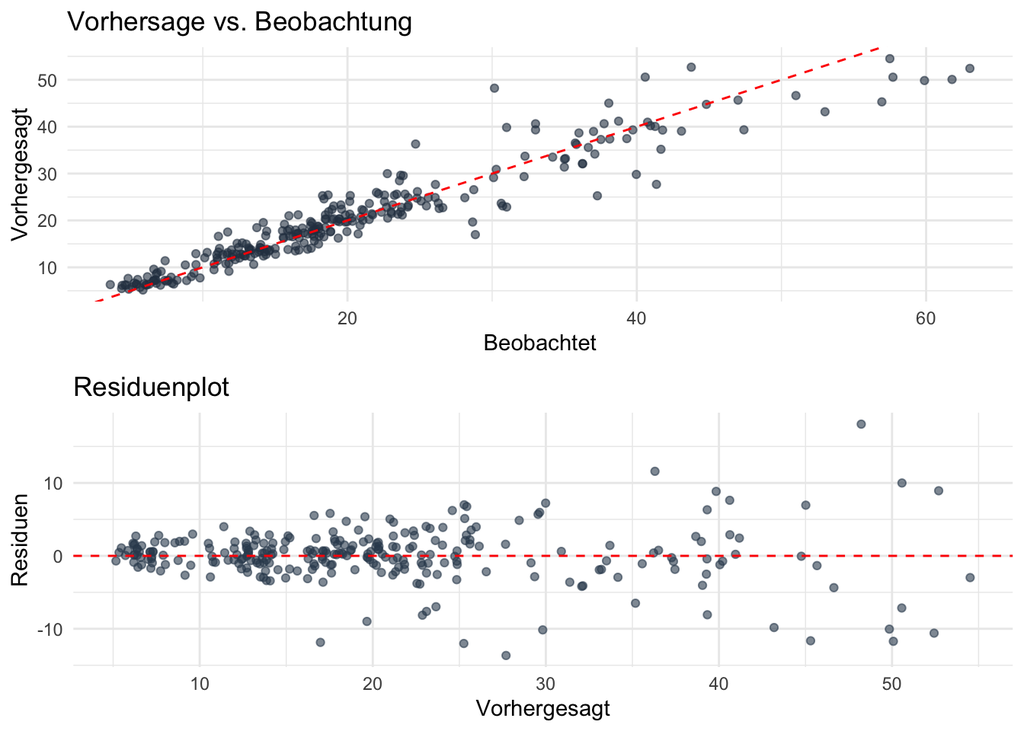

```r
#plot
rf_pipeline$plot_results()
```

## Leave One Site Out

```r
results_rf_df = data.frame()
df_obvervedVSpred = data.frame()

loso = FALSE

if(loso){

for(site in unique(df_transformed$Site)) {
  #Pipeline intialisieren:
  rf_pipeline = RandomForestPipeline_New$new(data = df_transformed,
                                             target = target,
                                             features = features)

  rf_pipeline$split(test_site = site, split_method = "LOSO") # aktuelle site aus dem training auslassen

  rf_pipeline$train(
    mtry = "efficient",
    cv_method = "repeatedcv",
    cv_folds = 3,
    cv_repeats = 3
  )  # modell trainieren

  rf_pipeline$predict() # vorhersage auf die aktuelle site erstellen

  loso_results = rf_pipeline$get_loso_predictions()

  site_results = rf_pipeline$evaluate(return_metric = TRUE) #metricen erstellen

  site_results$Site = site
  results_rf_df = rbind(results_rf_df, site_results)
  df_obvervedVSpred = rbind(df_obvervedVSpred, loso_results)

}}
```

Wir können jetzt auch eine SVM trainieren

```r
svm_pipeline = SVMPipeline_New$new(data = df_transformed,
                                      target = target,
                                      features = features)
```

```
## [2025-05-27 21:57:36.344941] Datensatzbereinigung: 965 von 967 Zeilen behalten (99.8%)
## [2025-05-27 21:57:36.345212] Neue Pipeline erzeugt.
## [2025-05-27 21:57:36.345313] Zielvariable: Ton
## [2025-05-27 21:57:36.345404] Features: K_percent, Th_ppm, K_Th_Ratio, TC_merged_cps, Geologie_1_5Mio_EU_Mapeolian_sand_peat, ... (75 weitere Features)
```

```r
svm_pipeline$split(test_size = 0.15)
```

```
## [2025-05-27 21:57:36.353616] Random Split durchgeführt. Trainset: 837 Testset: 128
```

```r
svm_pipeline$train()
```

```
## [2025-05-27 21:58:47.54253] SVM Modell erfolgreich trainiert
## [2025-05-27 21:58:47.542869] Beste Parameter - sigma: 0.1 C: 25
```

```r
svm_pipeline$predict()
```

```
## [2025-05-27 21:58:48.11053] Vorhersage abgeschlossen
```

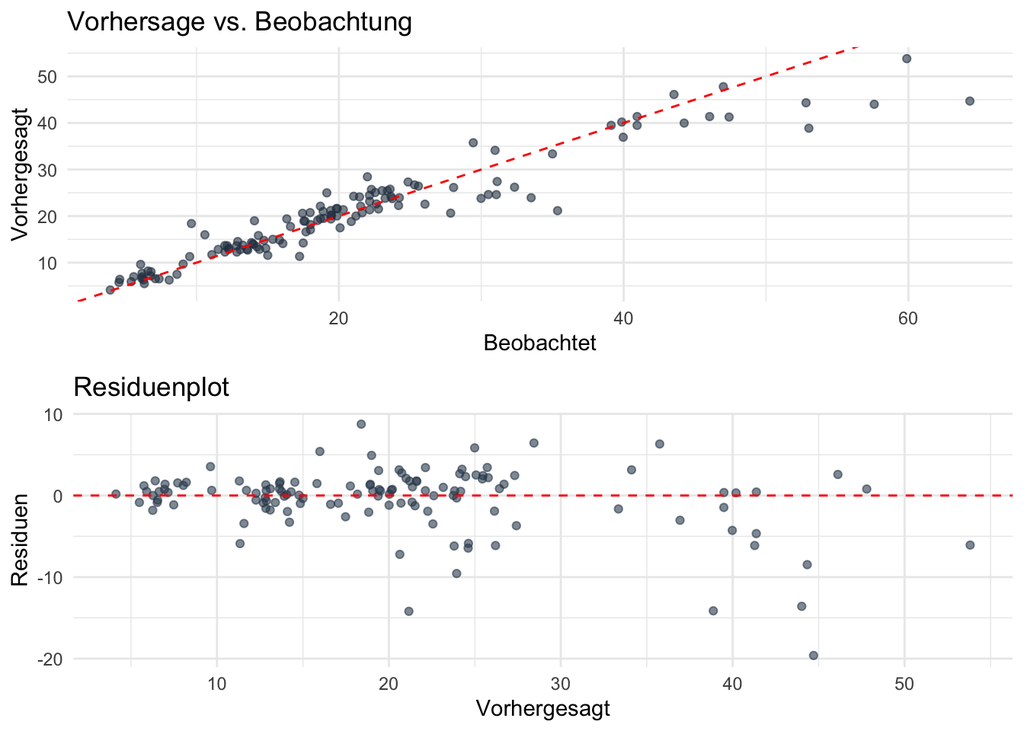

```r
svm_pipeline$plot_results()
```

```r
svm_pipeline$evaluate()
```

```
## [2025-05-27 21:58:48.538584] Evaluation abgeschlossen:
##       RMSE      MAE        R2      RPD     RPIQ       Bias
## 1 3.981366 2.496148 0.9066994 3.097059 2.807215 -0.4528307
```